# Kaggle Competition Documentation - DS2 Exam

Cosmin Catalin Ticu

4/10/2021

# Preface & Package Loading

The Github repo for this Kaggle competition project can be found [here](https://github.com/cosmin-ticu/kaggle-classification-competition).

```r
rm(list = ls())
library(tidyverse) # for data manipulation
library(h2o) # for building models
library(skimr) # summary statistics
library(GGally) # variable correlations
h2o.init(min_mem_size = '4g', max_mem_size = '8g') # pick more capable memory
```

[output not shown]

```r
my_seed <- 12345
```

# Introduction

The goal of this report is to summarize the efforts to build complex predictive models in order to classify whether an article of a certain type and of certain SEO features will be popular or not. The dataset comes from Mashable and it has been redistributed through the [CEU MS BA Kaggle Competition 2021](https://www.kaggle.com/c/ml2021ceuba). The goal of the competition is to achieve a minimum AUC on validation/test set above 0.65. All of the models employed within this study achieved this metric, as no baseline logit or probit models were used, thus directly jumping to more complex predictions.

# Data Cleaning

```r
# import data
train <- read_csv("F:/OneDrive - Central European University/Courses/Winter_Term/Data Science 2/kaggle-classification-competition/data/train.csv")
test <- read_csv("F:/OneDrive - Central European University/Courses/Winter_Term/Data Science 2/kaggle-classification-competition/data/test.csv")
```

After loading in the training and test set, we observe the structure of either of the datasets to see the variables that we are dealing with.

```r
# check variable types
str(train)
```

```
## spec_tbl_df [27,752 x 60] (S3: spec_tbl_df/tbl_df/tbl/data.frame)
##  $ n_tokens_title               : num [1:27752] 9 9 13 10 10 9 10 9 8 12 ...
##  $ n_tokens_content             : num [1:27752] 255 211 1072 370 231 ...
##  $ n_unique_tokens              : num [1:27752] 0.605 0.575 0.416 0.56 0.636 ...
##  $ n_non_stop_words             : num [1:27752] 1 1 1 1 1 ...
##  $ n_non_stop_unique_tokens     : num [1:27752] 0.792 0.664 0.541 0.698 0.797 ...
##  $ num_hrefs                    : num [1:27752] 3 3 19 2 4 11 7 4 19 10 ...
##  $ num_self_hrefs               : num [1:27752] 1 1 19 2 1 0 0 2 3 0 ...
##  $ num_imgs                     : num [1:27752] 1 1 20 0 1 1 1 0 9 1 ...
##  $ num_videos                   : num [1:27752] 0 0 0 0 1 0 0 21 0 0 ...
##  $ average_token_length         : num [1:27752] 4.91 4.39 4.68 4.36 5.09 ...
##  $ num_keywords                 : num [1:27752] 4 6 7 9 5 8 7 6 7 6 ...
##  $ data_channel_is_lifestyle    : num [1:27752] 0 0 0 0 0 0 1 0 0 0 ...
##  $ data_channel_is_entertainment: num [1:27752] 0 0 0 0 0 0 0 0 0 0 ...
##  $ data_channel_is_bus          : num [1:27752] 1 1 0 0 0 0 0 0 0 0 ...
##  $ data_channel_is_socmed       : num [1:27752] 0 0 0 0 0 0 0 0 0 0 ...
##  $ data_channel_is_tech         : num [1:27752] 0 0 1 1 0 0 0 0 0 0 ...
##  $ data_channel_is_world        : num [1:27752] 0 0 0 0 1 1 0 0 0 1 ...
##  $ kw_min_min                   : num [1:27752] 0 0 0 0 0 0 0 0 0 0 ...
##  $ kw_max_min                   : num [1:27752] 0 0 0 0 0 0 0 0 0 0 ...
##  $ kw_avg_min                   : num [1:27752] 0 0 0 0 0 0 0 0 0 0 ...
##  $ kw_min_max                   : num [1:27752] 0 0 0 0 0 0 0 0 0 0 ...
##  $ kw_max_max                   : num [1:27752] 0 0 0 0 0 0 0 0 0 0 ...
##  $ kw_avg_max                   : num [1:27752] 0 0 0 0 0 0 0 0 0 0 ...
##  $ kw_min_avg                   : num [1:27752] 0 0 0 0 0 0 0 0 0 0 ...
##  $ kw_max_avg                   : num [1:27752] 0 0 0 0 0 0 0 0 0 0 ...
##  $ kw_avg_avg                   : num [1:27752] 0 0 0 0 0 0 0 0 0 0 ...
##  $ self_reference_min_shares    : num [1:27752] 0 918 545 8500 0 0 0 770 4800 0 ...
##  $ self_reference_max_shares    : num [1:27752] 0 918 16000 8500 0 0 0 22800 4800 0 ...
##  $ self_reference_avg_sharess   : num [1:27752] 0 918 3151 8500 0 ...
##  $ weekday_is_monday            : num [1:27752] 1 1 1 1 1 1 1 1 1 1 ...
##  $ weekday_is_tuesday           : num [1:27752] 0 0 0 0 0 0 0 0 0 0 ...
##  $ weekday_is_wednesday         : num [1:27752] 0 0 0 0 0 0 0 0 0 0 ...
##  $ weekday_is_thursday          : num [1:27752] 0 0 0 0 0 0 0 0 0 0 ...
##  $ weekday_is_friday            : num [1:27752] 0 0 0 0 0 0 0 0 0 0 ...
##  $ weekday_is_saturday          : num [1:27752] 0 0 0 0 0 0 0 0 0 0 ...
##  $ weekday_is_sunday            : num [1:27752] 0 0 0 0 0 0 0 0 0 0 ...
##  $ is_weekend                   : num [1:27752] 0 0 0 0 0 0 0 0 0 0 ...
##  $ LDA_00                       : num [1:27752] 0.7998 0.2178 0.0286 0.0222 0.04 ...
##  $ LDA_01                       : num [1:27752] 0.05 0.0333 0.0288 0.3067 0.04 ...
```

[output cut: 69 more lines]

```
##   ..   rate_positive_words = col_double(),
##   ..   rate_negative_words = col_double(),
##   ..   avg_positive_polarity = col_double(),
##   ..   min_positive_polarity = col_double(),
##   ..   max_positive_polarity = col_double(),
##   ..   avg_negative_polarity = col_double(),
##   ..   min_negative_polarity = col_double(),
##   ..   max_negative_polarity = col_double(),
##   ..   title_subjectivity = col_double(),
##   ..   title_sentiment_polarity = col_double(),
##   ..   abs_title_subjectivity = col_double(),
##   ..   abs_title_sentiment_polarity = col_double(),
##   ..   is_popular = col_double(),
##   ..   article_id = col_double()
##   .. )
```

There are 27752 observations in the train set, while the test set has 11892 observations. A total of 60 features are present in the dataset, some spanning factor, some dummy and some numeric variables all relating to SEO measures such as article tokens, sentiment, rate of word appearance, mentions etc. With the aim of predicting whether an article is popular or not, we aim to select all the worthwhile variables without jeopardizing predictability or multicollinearity.

The first change we make pertains to the factor variables to be converted into actual factors readable by R.

```r
my_fun <- function(x) {
      x %>% mutate(
    data_channel_is_lifestyle = factor(data_channel_is_lifestyle),
    data_channel_is_entertainment = factor(data_channel_is_entertainment),
    data_channel_is_bus = factor(data_channel_is_bus),
    data_channel_is_socmed = factor(data_channel_is_socmed),
    data_channel_is_tech = factor(data_channel_is_tech),
    data_channel_is_world = factor(data_channel_is_world),
    weekday_is_monday = factor(weekday_is_monday),
    weekday_is_tuesday = factor(weekday_is_tuesday),
    weekday_is_wednesday = factor(weekday_is_wednesday),
    weekday_is_thursday = factor(weekday_is_thursday),
    weekday_is_friday = factor(weekday_is_friday),
    weekday_is_saturday = factor(weekday_is_saturday),
    weekday_is_sunday = factor(weekday_is_sunday),
    is_weekend = factor(is_weekend),
    article_id = factor(article_id),
)
}
result <- list( train, test ) %>%
    lapply( my_fun )
train <- result[[1]]
test <- result[[2]]

# convert outcome variable to a 2 level factor
train <- train %>%
  mutate(is_popular = factor(is_popular, levels = c(0,1), labels = c('no','yes')))
```

Looking at the class and type of each variable, we see that we are only dealing with numeric values, sometimes found in continous variables and sometimes in factorized variables.

```r
#display the class and type of each columns
sapply(train, class)
```

```
##                n_tokens_title              n_tokens_content
##                     "numeric"                     "numeric"
##               n_unique_tokens              n_non_stop_words
##                     "numeric"                     "numeric"
##      n_non_stop_unique_tokens                     num_hrefs
##                     "numeric"                     "numeric"
##                num_self_hrefs                      num_imgs
##                     "numeric"                     "numeric"
##                    num_videos          average_token_length
##                     "numeric"                     "numeric"
##                  num_keywords     data_channel_is_lifestyle
##                     "numeric"                      "factor"
## data_channel_is_entertainment           data_channel_is_bus
##                      "factor"                      "factor"
##        data_channel_is_socmed          data_channel_is_tech
##                      "factor"                      "factor"
##         data_channel_is_world                    kw_min_min
##                      "factor"                     "numeric"
##                    kw_max_min                    kw_avg_min
##                     "numeric"                     "numeric"
##                    kw_min_max                    kw_max_max
##                     "numeric"                     "numeric"
##                    kw_avg_max                    kw_min_avg
##                     "numeric"                     "numeric"
##                    kw_max_avg                    kw_avg_avg
##                     "numeric"                     "numeric"
##     self_reference_min_shares     self_reference_max_shares
##                     "numeric"                     "numeric"
##    self_reference_avg_sharess             weekday_is_monday
##                     "numeric"                      "factor"
##            weekday_is_tuesday          weekday_is_wednesday
##                      "factor"                      "factor"
##           weekday_is_thursday             weekday_is_friday
##                      "factor"                      "factor"
##           weekday_is_saturday             weekday_is_sunday
##                      "factor"                      "factor"
##                    is_weekend                        LDA_00
##                      "factor"                     "numeric"
##                        LDA_01                        LDA_02
##                     "numeric"                     "numeric"
##                        LDA_03                        LDA_04
##                     "numeric"                     "numeric"
##           global_subjectivity     global_sentiment_polarity
##                     "numeric"                     "numeric"
##    global_rate_positive_words    global_rate_negative_words
##                     "numeric"                     "numeric"
##           rate_positive_words           rate_negative_words
##                     "numeric"                     "numeric"
##         avg_positive_polarity         min_positive_polarity
##                     "numeric"                     "numeric"
##         max_positive_polarity         avg_negative_polarity
##                     "numeric"                     "numeric"
##         min_negative_polarity         max_negative_polarity
##                     "numeric"                     "numeric"
##            title_subjectivity      title_sentiment_polarity
##                     "numeric"                     "numeric"
##        abs_title_subjectivity  abs_title_sentiment_polarity
##                     "numeric"                     "numeric"
##                    is_popular                    article_id
##                      "factor"                      "factor"
```

```r
sapply(train, typeof)
```

```
##                n_tokens_title              n_tokens_content
##                      "double"                      "double"
##               n_unique_tokens              n_non_stop_words
##                      "double"                      "double"
##      n_non_stop_unique_tokens                     num_hrefs
##                      "double"                      "double"
##                num_self_hrefs                      num_imgs
##                      "double"                      "double"
##                    num_videos          average_token_length
##                      "double"                      "double"
##                  num_keywords     data_channel_is_lifestyle
##                      "double"                     "integer"
## data_channel_is_entertainment           data_channel_is_bus
##                     "integer"                     "integer"
##        data_channel_is_socmed          data_channel_is_tech
##                     "integer"                     "integer"
##         data_channel_is_world                    kw_min_min
##                     "integer"                      "double"
##                    kw_max_min                    kw_avg_min
##                      "double"                      "double"
##                    kw_min_max                    kw_max_max
##                      "double"                      "double"
##                    kw_avg_max                    kw_min_avg
##                      "double"                      "double"
##                    kw_max_avg                    kw_avg_avg
##                      "double"                      "double"
##     self_reference_min_shares     self_reference_max_shares
##                      "double"                      "double"
##    self_reference_avg_sharess             weekday_is_monday
##                      "double"                     "integer"
##            weekday_is_tuesday          weekday_is_wednesday
##                     "integer"                     "integer"
##           weekday_is_thursday             weekday_is_friday
##                     "integer"                     "integer"
##           weekday_is_saturday             weekday_is_sunday
##                     "integer"                     "integer"
##                    is_weekend                        LDA_00
##                     "integer"                      "double"
##                        LDA_01                        LDA_02
##                      "double"                      "double"
##                        LDA_03                        LDA_04
##                      "double"                      "double"
##           global_subjectivity     global_sentiment_polarity
##                      "double"                      "double"
##    global_rate_positive_words    global_rate_negative_words
##                      "double"                      "double"
##           rate_positive_words           rate_negative_words
##                      "double"                      "double"
##         avg_positive_polarity         min_positive_polarity
##                      "double"                      "double"
##         max_positive_polarity         avg_negative_polarity
##                      "double"                      "double"
##         min_negative_polarity         max_negative_polarity
##                      "double"                      "double"
##            title_subjectivity      title_sentiment_polarity
##                      "double"                      "double"
##        abs_title_subjectivity  abs_title_sentiment_polarity
##                      "double"                      "double"
##                    is_popular                    article_id
##                     "integer"                     "integer"
```

Searching for missing values:

```r
# where do we have missing values?
to_filter <- sapply(setdiff(names(train),'is_popular'), function(x) sum(is.na(x)))
print(paste("The following columns contain missing values", to_filter[to_filter > 0]))
```

```
## [1] "The following columns contain missing values "
```

```r
# no missing values
```

As we can see, no columns contain any missing values. This allows us to proceed with skimming the data and obtaining summary statistics to determine the best feature engineering practices.

```r
# taking a look at all the variables (identify skews for feature engineering)
skim(train)
```

Data summary

| Name | train |
| --- | --- |
| Number of rows | 27752 |
| Number of columns | 60 |
| _______________________ |  |
| Column type frequency: |  |
| factor | 16 |
| numeric | 44 |
| ________________________ |  |
| Group variables | None |

**Variable type: factor**

| skim_variable | n_missing | complete_rate | ordered | n_unique | top_counts |
| --- | --- | --- | --- | --- | --- |
| data_channel_is_lifestyle | 0 | 1 | FALSE | 2 | 0: 26258, 1: 1494 |
| data_channel_is_entertainment | 0 | 1 | FALSE | 2 | 0: 22833, 1: 4919 |
| data_channel_is_bus | 0 | 1 | FALSE | 2 | 0: 23375, 1: 4377 |
| data_channel_is_socmed | 0 | 1 | FALSE | 2 | 0: 26133, 1: 1619 |
| data_channel_is_tech | 0 | 1 | FALSE | 2 | 0: 22549, 1: 5203 |
| data_channel_is_world | 0 | 1 | FALSE | 2 | 0: 21899, 1: 5853 |
| weekday_is_monday | 0 | 1 | FALSE | 2 | 0: 23088, 1: 4664 |
| weekday_is_tuesday | 0 | 1 | FALSE | 2 | 0: 22589, 1: 5163 |
| weekday_is_wednesday | 0 | 1 | FALSE | 2 | 0: 22544, 1: 5208 |
| weekday_is_thursday | 0 | 1 | FALSE | 2 | 0: 22621, 1: 5131 |
| weekday_is_friday | 0 | 1 | FALSE | 2 | 0: 23804, 1: 3948 |
| weekday_is_saturday | 0 | 1 | FALSE | 2 | 0: 26031, 1: 1721 |
| weekday_is_sunday | 0 | 1 | FALSE | 2 | 0: 25835, 1: 1917 |
| is_weekend | 0 | 1 | FALSE | 2 | 0: 24114, 1: 3638 |
| is_popular | 0 | 1 | FALSE | 2 | no: 22286, yes: 5466 |
| article_id | 0 | 1 | FALSE | 27752 | 2: 1, 3: 1, 5: 1, 6: 1 |

**Variable type: numeric**

| skim_variable | n_missing | complete_rate | mean | sd | p0 | p25 | p50 | p75 | p100 | hist |
| --- | --- | --- | --- | --- | --- | --- | --- | --- | --- | --- |
| n_tokens_title | 0 | 1 | 10.38 | 2.11 | 3.00 | 9.00 | 10.00 | 12.00 | 20.00 | ▁▅▇▁▁ |
| n_tokens_content | 0 | 1 | 546.56 | 471.66 | 0.00 | 246.00 | 409.00 | 717.00 | 7764.00 | ▇▁▁▁▁ |
| n_unique_tokens | 0 | 1 | 0.56 | 4.21 | 0.00 | 0.47 | 0.54 | 0.61 | 701.00 | ▇▁▁▁▁ |
| n_non_stop_words | 0 | 1 | 1.01 | 6.25 | 0.00 | 1.00 | 1.00 | 1.00 | 1042.00 | ▇▁▁▁▁ |
| n_non_stop_unique_tokens | 0 | 1 | 0.70 | 3.90 | 0.00 | 0.63 | 0.69 | 0.75 | 650.00 | ▇▁▁▁▁ |
| num_hrefs | 0 | 1 | 10.92 | 11.40 | 0.00 | 4.00 | 8.00 | 14.00 | 304.00 | ▇▁▁▁▁ |
| num_self_hrefs | 0 | 1 | 3.30 | 3.85 | 0.00 | 1.00 | 3.00 | 4.00 | 116.00 | ▇▁▁▁▁ |
| num_imgs | 0 | 1 | 4.61 | 8.36 | 0.00 | 1.00 | 1.00 | 4.00 | 111.00 | ▇▁▁▁▁ |
| num_videos | 0 | 1 | 1.23 | 4.07 | 0.00 | 0.00 | 0.00 | 1.00 | 91.00 | ▇▁▁▁▁ |
| average_token_length | 0 | 1 | 4.55 | 0.84 | 0.00 | 4.48 | 4.66 | 4.86 | 8.04 | ▁▁▇▃▁ |
| num_keywords | 0 | 1 | 7.23 | 1.91 | 1.00 | 6.00 | 7.00 | 9.00 | 10.00 | ▁▂▇▇▇ |
| kw_min_min | 0 | 1 | 26.26 | 69.82 | -1.00 | -1.00 | -1.00 | 4.00 | 377.00 | ▇▁▁▁▁ |
| kw_max_min | 0 | 1 | 1165.99 | 4147.64 | 0.00 | 448.00 | 662.00 | 1000.00 | 298400.00 | ▇▁▁▁▁ |
| kw_avg_min | 0 | 1 | 314.70 | 670.78 | -1.00 | 142.50 | 235.94 | 358.22 | 42827.86 | ▇▁▁▁▁ |
| kw_min_max | 0 | 1 | 13529.57 | 57297.42 | 0.00 | 0.00 | 1400.00 | 7900.00 | 843300.00 | ▇▁▁▁▁ |
| kw_max_max | 0 | 1 | 751996.26 | 214875.42 | 0.00 | 843300.00 | 843300.00 | 843300.00 | 843300.00 | ▁▁▁▁▇ |
| kw_avg_max | 0 | 1 | 258825.28 | 134555.01 | 0.00 | 172477.50 | 244297.86 | 330700.00 | 843300.00 | ▃▇▃▁▁ |
| kw_min_avg | 0 | 1 | 1118.68 | 1138.40 | -1.00 | 0.00 | 1024.77 | 2060.03 | 3613.04 | ▇▃▃▂▂ |
| kw_max_avg | 0 | 1 | 5676.57 | 6346.89 | 0.00 | 3566.30 | 4359.61 | 6018.30 | 298400.00 | ▇▁▁▁▁ |
| kw_avg_avg | 0 | 1 | 3140.74 | 1343.01 | 0.00 | 2387.63 | 2870.55 | 3608.71 | 43567.66 | ▇▁▁▁▁ |
| self_reference_min_shares | 0 | 1 | 4123.98 | 20926.43 | 0.00 | 638.00 | 1200.00 | 2700.00 | 843300.00 | ▇▁▁▁▁ |
| self_reference_max_shares | 0 | 1 | 10401.31 | 41383.32 | 0.00 | 1100.00 | 2800.00 | 7900.00 | 843300.00 | ▇▁▁▁▁ |
| self_reference_avg_sharess | 0 | 1 | 6479.49 | 24979.25 | 0.00 | 978.79 | 2200.00 | 5199.40 | 843300.00 | ▇▁▁▁▁ |
| LDA_00 | 0 | 1 | 0.18 | 0.26 | 0.00 | 0.03 | 0.03 | 0.24 | 0.92 | ▇▁▁▁▁ |
| LDA_01 | 0 | 1 | 0.14 | 0.22 | 0.00 | 0.03 | 0.03 | 0.15 | 0.93 | ▇▁▁▁▁ |
| LDA_02 | 0 | 1 | 0.21 | 0.28 | 0.00 | 0.03 | 0.04 | 0.33 | 0.92 | ▇▁▁▁▁ |
| LDA_03 | 0 | 1 | 0.22 | 0.30 | 0.00 | 0.03 | 0.04 | 0.38 | 0.93 | ▇▁▁▁▂ |
| LDA_04 | 0 | 1 | 0.24 | 0.29 | 0.00 | 0.03 | 0.04 | 0.40 | 0.93 | ▇▂▁▁▂ |
| global_subjectivity | 0 | 1 | 0.44 | 0.12 | 0.00 | 0.40 | 0.45 | 0.51 | 1.00 | ▁▃▇▁▁ |
| global_sentiment_polarity | 0 | 1 | 0.12 | 0.10 | -0.39 | 0.06 | 0.12 | 0.18 | 0.73 | ▁▂▇▁▁ |
| global_rate_positive_words | 0 | 1 | 0.04 | 0.02 | 0.00 | 0.03 | 0.04 | 0.05 | 0.16 | ▅▇▁▁▁ |
| global_rate_negative_words | 0 | 1 | 0.02 | 0.01 | 0.00 | 0.01 | 0.02 | 0.02 | 0.18 | ▇▁▁▁▁ |
| rate_positive_words | 0 | 1 | 0.68 | 0.19 | 0.00 | 0.60 | 0.71 | 0.80 | 1.00 | ▁▁▃▇▃ |
| rate_negative_words | 0 | 1 | 0.29 | 0.16 | 0.00 | 0.19 | 0.28 | 0.38 | 1.00 | ▅▇▃▁▁ |
| avg_positive_polarity | 0 | 1 | 0.35 | 0.10 | 0.00 | 0.31 | 0.36 | 0.41 | 1.00 | ▁▇▃▁▁ |
| min_positive_polarity | 0 | 1 | 0.10 | 0.07 | 0.00 | 0.05 | 0.10 | 0.10 | 1.00 | ▇▁▁▁▁ |
| max_positive_polarity | 0 | 1 | 0.76 | 0.25 | 0.00 | 0.60 | 0.80 | 1.00 | 1.00 | ▁▁▅▅▇ |
| avg_negative_polarity | 0 | 1 | -0.26 | 0.13 | -1.00 | -0.33 | -0.25 | -0.19 | 0.00 | ▁▁▂▇▃ |
| min_negative_polarity | 0 | 1 | -0.52 | 0.29 | -1.00 | -0.70 | -0.50 | -0.30 | 0.00 | ▆▆▇▅▅ |
| max_negative_polarity | 0 | 1 | -0.11 | 0.10 | -1.00 | -0.12 | -0.10 | -0.05 | 0.00 | ▁▁▁▁▇ |
| title_subjectivity | 0 | 1 | 0.28 | 0.32 | 0.00 | 0.00 | 0.15 | 0.50 | 1.00 | ▇▂▂▁▂ |
| title_sentiment_polarity | 0 | 1 | 0.07 | 0.27 | -1.00 | 0.00 | 0.00 | 0.15 | 1.00 | ▁▁▇▂▁ |
| abs_title_subjectivity | 0 | 1 | 0.34 | 0.19 | 0.00 | 0.17 | 0.50 | 0.50 | 0.50 | ▃▂▁▁▇ |
| abs_title_sentiment_polarity | 0 | 1 | 0.16 | 0.23 | 0.00 | 0.00 | 0.00 | 0.25 | 1.00 | ▇▂▁▁▁ |

Skimming the variables, we notice a few that are skewed. Ideally, to achieve the absolute best AUC performance, one would convert all the skewed variables to log and then employ both their level and log forms in the final model. However, for the sake of good statistical conduct, we convert the skewed variables to log to use in a different predictor set in order to benchmark against the level variables.

# Feature Engineering

Looking at the correlations between extremely similar variables, we notice:

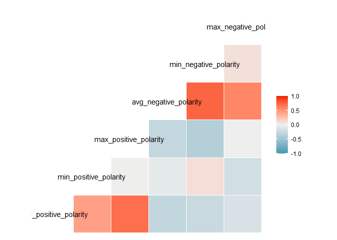

```r
# check correlations between polarity and subjectivity measures
ggcorr(subset(train,select = c(avg_positive_polarity,min_positive_polarity,max_positive_polarity,
                               avg_negative_polarity,min_negative_polarity,max_negative_polarity)))
```

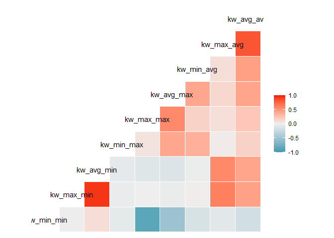

```r
# check correlations between keyword measures
ggcorr(subset(train,select = c(kw_min_min, kw_max_min, kw_avg_min,
                               kw_min_max, kw_max_max, kw_avg_max,
                               kw_min_avg, kw_max_avg, kw_avg_avg)))
```

```r
# drop averages keep mins & maxs
```

As the measures for polarity are plentiful, so are the multicollinearity possibilities. As such, as we are interested in a model that is not overfitted, we aim to remove the variables that highly correlate with each other (above 80% is a standard benchmark). One could choose to either keep the averages or keep only the mins and maxes. For the sake of achieving a better performance from a more complex model, we get rid of the averages of all the polarity and keyword share metrics.

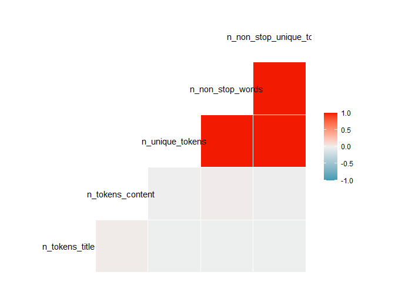

```r
# check correlations between word measures
ggcorr(subset(train,select = c(n_tokens_title, n_tokens_content,
                               n_unique_tokens, n_non_stop_words,
                               n_non_stop_unique_tokens)))
```

```r
# exclude rate of unique tokens as correlation with rate of non-stop unique tokens
# is extremely high (as expected)
```

Looking at the correlations between the token variables, it is not worthwhile to keep the unique and non-unique counterparts as they might overfit the model. As such, we check to see the distribution of the rate of non stop words.

```r
# n_non_stop_words is almost always 1 so I exclude it
print(paste("There are",
            nrow(train %>% dplyr::filter(n_non_stop_words > 0.99)),
            "observations where the rate of non-stop words is over 99%"))
```

```
## [1] "There are 26934 observations where the rate of non-stop words is over 99%"
```

As n_non_stop_words (rate of non-stop words) is almost always 1 (over 90% of cases), I will exclude it from this analysis.

A better measure of self references is rather in percentages than absolute values, as it is also makes more sense to the researcher and to SEO standards.

```r
# add the links to Mashable.com as the percentage of the total links in the article
train <- train %>% mutate(
  perc_self_hrefs = ifelse( num_hrefs == 0, 0, num_self_hrefs / num_hrefs))
test <- test %>% mutate(
  perc_self_hrefs = ifelse( num_hrefs == 0, 0, num_self_hrefs / num_hrefs))
```

Accordingly, we proceed to remove all redundant variables, highly correlated ones and one of the rates for positive or negative words as they signal the exact same matter (they are just % opposites). Furthermore, the weekend dummy variable is excluded as there are already dummies for each day of the week.

```r
# rate_positive_words and rate_negative_words sum up to 1 --> keep only one
# remove redundant is_weekend as weekday dummies already exist
to_drop <- c("rate_negative_words", "abs_title_subjectivity",
             "abs_title_sentiment_polarity", "avg_positive_polarity",
             "avg_negative_polarity", "is_weekend",
             "self_reference_avg_sharess", "kw_min_avg", "kw_max_avg",
             "kw_avg_avg", "kw_avg_min", "kw_avg_max","num_self_hrefs",
             "n_non_stop_words", "n_unique_tokens")

# drop listed variables
train <- subset(train, select = setdiff(names(train), to_drop))
test <- subset(test, select = setdiff(names(test), to_drop))
```

Looking at the variables that have values lower than 0, we aim to check whether they have the right values or whether some contain negatives which should not be there.

```r
# check the variables which have values lower than 0
temp <- Filter(is.numeric, train)
for (col in names(temp)){
  min <- min(temp[,col])
  if (min < 0){
   print(c(col, min))
  } else {
    next
  }
}
```

```
## [1] "kw_min_min" "-1"
## [1] "global_sentiment_polarity" "-0.39375"
## [1] "min_negative_polarity" "-1"
## [1] "max_negative_polarity" "-1"
## [1] "title_sentiment_polarity" "-1"
```

```r
# some of them cannot be negative

print(paste("There are",
            nrow(train %>% dplyr::filter(kw_min_min < 0)),
            "observations (over 50% of dataset) where the minimum number of shares is negative"))
```

```
## [1] "There are 16059 observations (over 50% of dataset) where the minimum number of shares is negative"
```

As is the case with the minimum of the minimum of number of keyword shares, we remove the variable. The number of keyword shares should never be negative. At its lowest it should be 0, thus signaling no shares.

```r
# drop that stuff

train <- subset(train, select = setdiff(names(train), "kw_min_min"))
test <- subset(test, select = setdiff(names(test), "kw_min_min"))
```

Looking at correlations between all of the kept variables, we do not observe any more highly correlated variables.

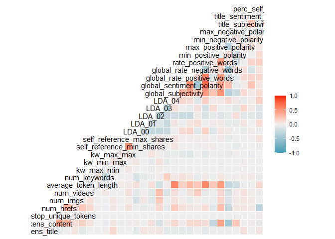

```r
# Correlation matrix of all kept variables
ggcorr(Filter(is.numeric, train))
```

We now proceed to add log values to the designated skewed numeric variables. For the values that are either 0 or negative, we proceed either with data imputation of a 1 for absolute count measures and with the inputation of half of the mean for the non-count values. The addition of half of the mean value is a common choice in data imputation when logs are created.

```r
# add logs of skewed features to train
my_fun_log <- function(x) {
      x %>% mutate(
  log_n_tokens_content = ifelse(n_tokens_content == 0, log(n_tokens_content+1), log(n_tokens_content)),
  log_n_non_stop_unique_tokens = ifelse(n_non_stop_unique_tokens == 0, log(n_non_stop_unique_tokens+1), log(n_non_stop_unique_tokens)),
  log_num_hrefs = ifelse(num_hrefs == 0, log(num_hrefs+1), log(num_hrefs)),
  log_num_imgs = ifelse(num_imgs == 0, log(num_imgs+1), log(num_imgs)),
  log_num_videos = ifelse(num_videos == 0, log(num_videos+1), log(num_videos)),
  log_kw_max_min = ifelse(kw_max_min == 0, log(kw_max_min+1), log(kw_max_min)),
  log_kw_min_max = ifelse(kw_min_max == 0, log(kw_min_max+1), log(kw_min_max)),
  log_self_reference_min_shares = ifelse(self_reference_min_shares == 0, log(self_reference_min_shares+1), log(self_reference_min_shares)),
  log_self_reference_max_shares = ifelse(self_reference_max_shares == 0, log(self_reference_max_shares+1), log(self_reference_max_shares)),
  log_LDA_00 = ifelse(LDA_00 == 0, log(LDA_00+ mean(LDA_00)/2), log(LDA_00)),
  log_LDA_01 = ifelse(LDA_01 == 0, log(LDA_01+ mean(LDA_01)/2), log(LDA_01)),
  log_LDA_02 = ifelse(LDA_02 == 0, log(LDA_02+ mean(LDA_02)/2), log(LDA_02)),
  log_LDA_03 = ifelse(LDA_03 == 0, log(LDA_03+ mean(LDA_03)/2), log(LDA_03)),
  log_LDA_04 = ifelse(LDA_04 == 0, log(LDA_04+ mean(LDA_04)/2), log(LDA_04)),
  log_global_rate_negative_words = ifelse(global_rate_negative_words == 0, log(global_rate_negative_words+ mean(global_rate_negative_words)/2), log(global_rate_negative_words)),
  log_min_positive_polarity = ifelse(min_positive_polarity == 0, log(min_positive_polarity+mean(min_positive_polarity)/2), log(min_positive_polarity))
)
}
result_log <- list( train, test ) %>%
    lapply( my_fun_log )
train <- result_log[[1]]
test <- result_log[[2]]
```

# Modelling Choices

Creating the predictor sets, we have a set with level numeric variables and one with log numeric variables.

```r
# create predictor sets
y <- 'is_popular'

# keep first 45 vars for level
x_level <- setdiff(names(train[, 1:45]), c("is_popular", "article_id"))

# set diff to level vars for log
x_log <- setdiff(names(train), c("is_popular", "article_id",
                                 "n_tokens_content", "n_non_stop_unique_tokens",
                                 "num_hrefs", "num_imgs", "num_videos",
                                 "kw_max_min", "kw_min_max",
                                 "self_reference_min_shares",
                                 "self_reference_max_shares",
                                 "LDA_00", "LDA_01", "LDA_02", "LDA_03", "LDA_04",
                                 "global_rate_negative_words", "min_positive_polarity"))
```

# Predictive Modelling

Five types of models were used for this analysis spanning Random Forest, Gradient Boosting, Penalized Linear (Lasso & Ridge), NN (an XGBoost was unfortunately not possible due to its incompatibility with h2o on Windows) and, finally, a combination of all the previous five under a stacked ensemble model. 5-fold cross-validation was used as a measure of avoiding overfitting. The R package of choice for this assignment was h2o due to its more efficient memory storage and model saving capabilities. Even so, running all of the models with grid searches and with different predictor sets (between level and log numeric vars) took extremely long to produce the desired outputs (about 1.5 hours for the whole rmd).

## (1) Split training data into train and validation sets

Ideally, to achieve the best possible performance in a Kaggle competition (where every hundreth of a percent matters), one should not include a validation set and just make the model comparisons on the cross-validated results. Nonetheless, statistical dogma prevails and begs for the inclusion of a validation set. The researcher is interested in as scientific of an experiment as possible rather than the absolute best performance metric.

For the data splitting, the new sets will also have to be loaded as h2o datasets into our local cluster.

```r
# keep 75% train and 25% validation
splits <- h2o.splitFrame(as.h2o(train), ratios = 0.75, seed = my_seed)
data_train <- splits[[1]]
data_valid <- splits[[2]]

data_test <- as.h2o(test)
```

For the model building, this report employs already loaded models from the local memory as the grid searches take too long for an RMD to knit successfully. As such, the best models out of the grids were saved as h2o objects and read into this report for evaluation metrics. The hyperparameters of the tuning grids will be explore and the best parameters of the final model of choice will be displayed for each grid search.

After saving the models, we (1) display the AUC values for the train, cross-validated and validation sets to check for overfitting, (2) calculate the predictions for the test set, (3) save them to a .csv file and (4) upload to Kaggle under the right format to benchmark in the competition.

## (2) Random Forest

To decide between the best predictor set, we will run the exact same h2o predictive model grid search with a random forest on the level numeric variables and the log ones, respectively.

The hyperparameters of choice for the tuning grid are: * Number of trees grown - 50, 100 or 200 * Number of variables to choose randomly at each split - 5, 12 or 18 * Sample Rate for bootstrap samples - 10%, 25% or 66% * Depth of trees - 5, 10 or 20

```r
# create parameter grid
# rf_params <- list(
#   ntrees = c(50, 100, 200), # number of trees grown
#   mtries = c(5, 12, 18), # number of variables to choose at each split
#   sample_rate = c(0.1, 0.25, 0.66), # sample rate for the bootstrap samples
#   max_depth = c(5, 10, 20) # depth of the trees
# )

# train model for level
# rf_grid_level <- h2o.grid(
#   "randomForest",
#   x = x_level, y = y,
#   training_frame = data_train,
#   grid_id = "rf_model_level",
#   nfolds = 5,
#   seed = my_seed,
#   hyper_params = rf_params,
#   validation_frame = data_valid,
#   keep_cross_validation_predictions = TRUE # needed for stacking
# )

# check AUC for different parameters
# h2o.getGrid(rf_grid_level@grid_id, sort_by = "auc", decreasing = TRUE)

# save best rf model
# best_rf_level <- h2o.getModel(
#   h2o.getGrid(rf_grid_level@grid_id, sort_by = "auc", decreasing = TRUE)@model_ids[[1]]
# )

# save model to file
# model_path <- h2o.saveModel(object = best_rf_level,
#                             path = "F:/OneDrive - Central European University/Courses/Winter_Term/Data Science 2/kaggle-classification-competition/models/",
#                             force = TRUE)

# import model from file
best_rf_level <- h2o.loadModel("F:/OneDrive - Central European University/Courses/Winter_Term/Data Science 2/kaggle-classification-competition/models/rf_model_level_model_75")

# Get summary of best parameters
knitr::kable(best_rf_level@model$model_summary %>% subset(select =
                                                        c(number_of_trees,
                                                          max_depth,
                                                          min_leaves,
                                                          max_leaves)), caption =
                "Best RF Level Model - Hyperparameters")
```

Best RF Level Model - Hyperparameters

| number_of_trees | max_depth | min_leaves | max_leaves |
| --- | --- | --- | --- |
| 200 | 20 | 2033 | 2856 |

```r
# get AUC for best rf model
rf_level_auc <- h2o.auc(best_rf_level, train = TRUE, xval = TRUE, valid = TRUE)

# prediction for test set
prediction <- h2o.predict(best_rf_level, newdata = data_test)
# bind predictions with article id-s
solution <- cbind(test[, 'article_id'], as.data.frame(prediction[, 3]))

# rename columns
colnames(solution) <- c('article_id', 'score')

# write to csv
write_csv(solution, 'F:/OneDrive - Central European University/Courses/Winter_Term/Data Science 2/kaggle-classification-competition/submissions/best_rf_level.csv')

### REDO above process for log vars to make comparison table
# train model for log vars
# rf_grid_log <- h2o.grid(
#   "randomForest",
#   x = x_log, y = y,
#   training_frame = data_train,
#   grid_id = "rf_model_log",
#   nfolds = 5,
#   seed = my_seed,
#   hyper_params = rf_params,
#   validation_frame = data_valid,
#   keep_cross_validation_predictions = TRUE # needed for stacking
# )
# best_rf_log <- h2o.getModel(
#   h2o.getGrid(rf_grid_log@grid_id, sort_by = "auc", decreasing = TRUE)@model_ids[[1]]
# )
# model_path <- h2o.saveModel(object = best_rf_log,
#                             path = "F:/OneDrive - Central European University/Courses/Winter_Term/Data Science 2/kaggle-classification-competition/models/",
#                             force = TRUE)
best_rf_log <- h2o.loadModel("F:/OneDrive - Central European University/Courses/Winter_Term/Data Science 2/kaggle-classification-competition/models/rf_model_log_model_74")
knitr::kable(subset(best_rf_log@model$model_summary,select =
                                                        c(number_of_trees,
                                                          max_depth,
                                                          min_leaves,
                                                          max_leaves)), caption =
                "Best RF Log Model - Hyperparameters")
```

Best RF Log Model - Hyperparameters

| number_of_trees | max_depth | min_leaves | max_leaves |
| --- | --- | --- | --- |
| 200 | 10 | 247 | 517 |

```r
rf_log_auc <- h2o.auc(best_rf_log, train = TRUE, xval = TRUE, valid = TRUE)
prediction <- h2o.predict(best_rf_log, newdata = data_test)
solution <- cbind(test[, 'article_id'], as.data.frame(prediction[, 3]))
colnames(solution) <- c('article_id', 'score')
write_csv(solution, 'F:/OneDrive - Central European University/Courses/Winter_Term/Data Science 2/kaggle-classification-competition/submissions/best_rf_log.csv')
```

Neither of the RF models appear to have overfitted the data as evidence by the AUC comparison table.

Now that we have built two identical RF grids in h2o, we can create a comparison table between the two best models to see their AUC performance. Accordingly, we will decide which predictor set to proceed with (either level numeric vars or log).

```r
### MODEL COMPARISON
# save models to a list
my_rf_models <- list(
  best_rf_level, best_rf_log
)

# create table with AUC values for different models
auc_on_valid_rf <- map_df(my_rf_models, ~{
  tibble(model = .@model_id, RMSE = h2o.rmse(., xval = TRUE), AUC_xval = h2o.auc(., xval = TRUE), AUC_valid = h2o.auc(h2o.performance(., data_valid)))
}) %>% arrange(AUC_valid)

names(auc_on_valid_rf) <- c("Model", "CV RMSE","CV AUC", "Validation Set AUC")

# print table
knitr::kable(auc_on_valid_rf, caption = "Performance comparison of RF models w/ different predictors", digits = 4)
```

Performance comparison of RF models w/ different predictors

| Model | CV RMSE | CV AUC | Validation Set AUC |
| --- | --- | --- | --- |
| rf_model_level_model_75 | 0.3827 | 0.6954 | 0.7009 |
| rf_model_log_model_74 | 0.3830 | 0.6965 | 0.7015 |

We will proceed with the log predictor set. The AUC performance gain is barely noticeable, however.

## (3) Gradient Boosting

We will run the log predictor set on an h2o predictive model grid search with a gradient boosting machine.

The hyperparameters of choice for the tuning grid are: * Number of trees grown - 10, 50, 100 or 300 (as GBM tends to require more trees) * Learning rate - 0.01, 0.05, 0.1 or 0.3 * Sample Rate for bootstrap samples - 20%, 50%, 80% or 100% * Depth of trees - 2 or 5

```r
# create parameter grid
# gbm_params <- list(
#   learn_rate = c(0.01, 0.05, 0.1, 0.3),
#   ntrees = c(10, 50, 100, 300),
#   max_depth = c(2, 5),
#   sample_rate = c(0.2, 0.5, 0.8, 1)
# )

# train model
# gbm_grid <- h2o.grid(
#   "gbm", x = x_log, y = y,
#   grid_id = "gbm_model",
#   training_frame = data_train,
#   nfolds = 5,
#   seed = my_seed,
#   hyper_params = gbm_params,
#   validation_frame = data_valid,
#   keep_cross_validation_predictions = TRUE # needed for stacking
# )

# check AUC for different parameters
# h2o.getGrid(gbm_grid@grid_id, sort_by = "auc", decreasing = TRUE)

# save best gbm model
# best_gbm <- h2o.getModel(
#   h2o.getGrid(gbm_grid@grid_id, sort_by = "auc", decreasing = TRUE)@model_ids[[1]]
# )

# save model to file
# model_path <- h2o.saveModel(object = best_gbm,
#                             path = "F:/OneDrive - Central European University/Courses/Winter_Term/Data Science 2/kaggle-classification-competition/models/",
#                             force = TRUE)

# import model from file
best_gbm <- h2o.loadModel("F:/OneDrive - Central European University/Courses/Winter_Term/Data Science 2/kaggle-classification-competition/models/gbm_model_model_86")

# Get summary of best parameters
knitr::kable(best_gbm@model$model_summary %>% subset(select =
                                                        c(number_of_trees,
                                                          max_depth,
                                                          min_leaves,
                                                          max_leaves)), caption =
                "Best GBM Model - Hyperparameters")
```

Best GBM Model - Hyperparameters

| number_of_trees | max_depth | min_leaves | max_leaves |
| --- | --- | --- | --- |
| 100 | 5 | 17 | 32 |

```r
# get AUC for best gbm model
gbm_auc <- h2o.auc(best_gbm, train = TRUE, xval = TRUE, valid = TRUE)

knitr::kable(t(gbm_auc), caption = "Best GBM Model - Train, CV & Validation AUC")
```

Best GBM Model - Train, CV & Validation AUC

| train | valid | xval |
| --- | --- | --- |
| 0.795155 | 0.7044076 | 0.6976928 |

```r
# prediction for test set
prediction <- h2o.predict(best_gbm, newdata = data_test)
# bind predictions with article id-s
solution <- cbind(test[, 'article_id'], as.data.frame(prediction[, 3]))

# rename columns
colnames(solution) <- c('article_id', 'score')

# write to csv
write_csv(solution, 'F:/OneDrive - Central European University/Courses/Winter_Term/Data Science 2/kaggle-classification-competition/submissions/best_gbm.csv')
```

The best GBM model appears to have a higher AUC on the training set, however it is not extremely high in comparison to the CV and Validation AUCs.

## (4) Lasso model

The lambda_search parameter set to true means that during the training many different values are tried. The one resulting in the lowest cross-validated error (loss function dependent) is picked for the final Lasso (same applies for the Ridge model). We print the lambda value for the final model (same applies for the Ridge model).

```r
# train lasso model with lambda search
# lasso_model <- h2o.glm(
#   x_log, y,
#   training_frame = data_train,
#   model_id = "lasso_model",
#   family = "binomial",
#   alpha = 1,
#   lambda_search = TRUE,
#   seed = my_seed,
#   nfolds = 5,
#   validation_frame = data_valid,
#   keep_cross_validation_predictions = TRUE # needed for stacking
# )

# save model to file
# model_path <- h2o.saveModel(object = lasso_model,
#                             path = "F:/OneDrive - Central European University/Courses/Winter_Term/Data Science 2/kaggle-classification-competition/models/",
#                             force = TRUE)

# import model from file
best_lasso <- h2o.loadModel("F:/OneDrive - Central European University/Courses/Winter_Term/Data Science 2/kaggle-classification-competition/models/lasso_model")

print(paste("The best identified lambda for the Lasso model is",
            best_lasso@model$lambda_best))
```

```
## [1] "The best identified lambda for the Lasso model is 0.000388097062019472"
```

```r
# get AUC for best lambda
lasso_auc <- h2o.auc(best_lasso, train = TRUE, xval = TRUE, valid = TRUE)

knitr::kable(t(lasso_auc), caption = "Best Lasso Model - Train, CV & Validation AUC")
```

Best Lasso Model - Train, CV & Validation AUC

| train | valid | xval |
| --- | --- | --- |
| 0.6751837 | 0.6741945 | 0.6694133 |

```r
# prediction for test set
prediction <- h2o.predict(best_lasso, newdata = data_test)
# bind predictions with article id-s
solution <- cbind(test[, 'article_id'], as.data.frame(prediction[, 3]))

# rename columns
colnames(solution) <- c('article_id', 'score')

# write to csv
write_csv(solution, 'F:/OneDrive - Central European University/Courses/Winter_Term/Data Science 2/kaggle-classification-competition/submissions/best_lasso.csv')
```

According to the AUC metrics, the Lasso model does not overfit the data.

## (5) Ridge model

```r
# train ridge model with lambda search
# ridge_model <- h2o.glm(
#   x_log, y,
#   training_frame = data_train,
#   model_id = "ridge_model",
#   family = "binomial",
#   alpha = 0,
#   lambda_search = TRUE,
#   seed = my_seed,
#   nfolds = 5,
#   validation_frame = data_valid,
#   keep_cross_validation_predictions = TRUE
# )

# save model to file
# model_path <- h2o.saveModel(object = ridge_model,
#                             path = "F:/OneDrive - Central European University/Courses/Winter_Term/Data Science 2/kaggle-classification-competition/models/",
#                             force = TRUE)

# import model from file
best_ridge <- h2o.loadModel("F:/OneDrive - Central European University/Courses/Winter_Term/Data Science 2/kaggle-classification-competition/models/ridge_model")

print(paste("The best identified lambda for the Ridge model is",
            best_ridge@model$lambda_best))
```

```
## [1] "The best identified lambda for the Ridge model is 0.00101441710919809"
```

```r
# get AUC for best lambda
ridge_auc <- h2o.auc(best_ridge, train = TRUE, xval = TRUE, valid = TRUE)

knitr::kable(t(ridge_auc), caption = "Best Ridge Model - Train, CV & Validation AUC")
```

Best Ridge Model - Train, CV & Validation AUC

| train | valid | xval |
| --- | --- | --- |
| 0.6753921 | 0.6746949 | 0.6695328 |

```r
# prediction for test set
prediction <- h2o.predict(best_ridge, newdata = data_test)
# bind predictions with article id-s
solution <- cbind(test[, 'article_id'], as.data.frame(prediction[, 3]))

# rename columns
colnames(solution) <- c('article_id', 'score')

# write to csv
write_csv(solution, 'F:/OneDrive - Central European University/Courses/Winter_Term/Data Science 2/kaggle-classification-competition/submissions/best_ridge.csv')
```

According to the AUC metrics, the Ridge model does not overfit the data.

## (6) Deep Neural Network

We will run the log predictor set on an h2o predictive model grid search with a deeplearning algorithm (dense neural networks).

The hyperparameters of choice for the tuning grid are (limited computational power restricted tinkering with more parameters): * Hidden layers (no. & size) - 32 & 32, 64 & 64 or 128 & 128 * Dropout ratios for the hidden layers - 40% & 60% or 20% & 80% * Learning rate - 0.01 or 0.02 * ReLu activation function * 30 epochs * 3 stopping rounds for unimproved performance stop limit * 1% stopping tolerance i.e. when misclassification does not improve by >=1% for 3 scoring events

```r
# create parameter grid
# nn_params <- list(
#   hidden=list(c(32,32),c(64,64),c(128,128)),
#   hidden_dropout_ratios = list(c(0.4, 0.6),c(0.2,0.8)),
#   rate=c(0.01,0.02) # learning rate
# )

# train model
# nn_grid <- h2o.grid(
#   algorithm="deeplearning",
#   x = x_log, y = y,
#   training_frame = data_train,
#   grid_id = "nn_model",
#   standardize = TRUE,
#   seed = my_seed,
#   nfolds = 5,
#   validation_frame = data_valid,
#   hyper_params = nn_params,
#   activation = "RectifierWithDropout", # ReLu + dropout because of dropout layers
#   epochs = 30, # standard number of epochs for computer not to catch on fire
#   stopping_rounds = 3, # 3 consecutive rounds of unimproved performance
#   stopping_metric = "AUC", # stopping metric of choice as this is classification
#   stopping_tolerance = 0.01, # stop when misclassification does not improve by >=1% for 3 scoring events
#   keep_cross_validation_predictions = TRUE # needed for stacking
# )

# check AUC for different parameters
# h2o.getGrid(nn_grid@grid_id, sort_by = "auc", decreasing = TRUE)

# save best gbm model
# best_nn <- h2o.getModel(
#   h2o.getGrid(nn_grid@grid_id, sort_by = "auc", decreasing = TRUE)@model_ids[[1]]
# )

# save model to file
# model_path <- h2o.saveModel(object = best_nn,
#                             path = "F:/OneDrive - Central European University/Courses/Winter_Term/Data Science 2/kaggle-classification-competition/models/",
#                             force = TRUE)

# import model from file
best_nn <- h2o.loadModel("F:/OneDrive - Central European University/Courses/Winter_Term/Data Science 2/kaggle-classification-competition/models/nn_model_model_9")

knitr::kable(best_nn@model$model_summary %>% subset(select =
                                                        c(layer,
                                                          units,
                                                          type,
                                                          dropout,
                                                          mean_rate,
                                                          mean_weight,
                                                          mean_bias)), caption =
                "Best Deeplearning (dense NN) Model - Hyperparameters")
```

Best Deeplearning (dense NN) Model - Hyperparameters

| layer | units | type | dropout | mean_rate | mean_weight | mean_bias |
| --- | --- | --- | --- | --- | --- | --- |
| 1 | 69 | Input | 0 | NA | NA | NA |
| 2 | 128 | RectifierDropout | 40 | 0.1947878 | -0.0142875 | 0.4264250 |
| 3 | 128 | RectifierDropout | 60 | 0.0076732 | -0.0444390 | 0.6754169 |
| 4 | 2 | Softmax | NA | 0.0029076 | 0.0149352 | 0.0092168 |

```r
# get AUC for best neural network model
nn_auc <- h2o.auc(best_nn, train = TRUE, xval = TRUE, valid = TRUE)

knitr::kable(t(nn_auc), caption = "Best Deeplearning Model - Train, CV & Validation AUC")
```

Best Deeplearning Model - Train, CV & Validation AUC

| train | valid | xval |
| --- | --- | --- |
| 0.7301649 | 0.6908626 | 0.6829053 |

```r
# prediction for test set
prediction <- h2o.predict(best_nn, newdata = data_test)
# bind predictions with article id-s
solution <- cbind(test[, 'article_id'], as.data.frame(prediction[, 3]))

# rename columns
colnames(solution) <- c('article_id', 'score')

# write to csv
write_csv(solution, 'F:/OneDrive - Central European University/Courses/Winter_Term/Data Science 2/kaggle-classification-competition/submissions/best_nn.csv')
```

According to the AUC metrics, the deeplearning model does not appear to have overfitted the data.

## (7) Stacked model

Lastly, we built a stacked ensemble model (combination of all the previously built models) with a glm (penalized linear model) as the meta learner.

Due to its nature of working directly with the base models’ predictions rather than their parameters, stacked models work best when the base learner models are not highly correlated.

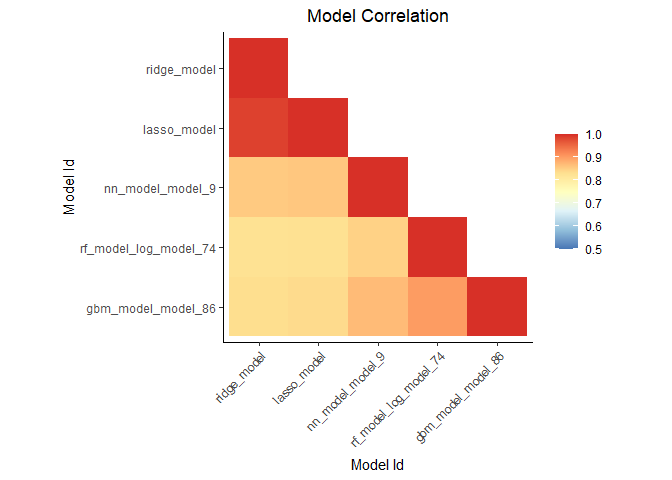

```r
# save models to a list
base_learners <- list(
  best_rf_log, best_gbm, best_nn, best_ridge, best_lasso
)

# check correlation between models
h2o.model_correlation_heatmap(base_learners, data_valid)
```

Because of the high correlation between the two penalized linear models, the one with better performance will be used for stacking (i.e. Ridge).

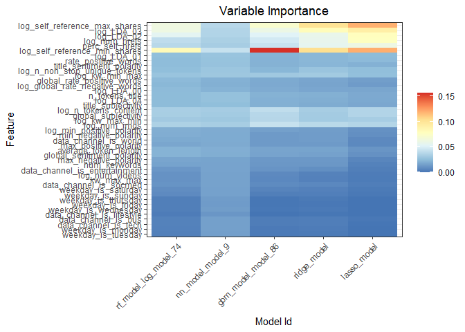

```r
# check correlation between variable importance of models
h2o.varimp_heatmap(base_learners)
```

Overall, we can see that the deeplearning model kept variable importance quite even throughout, while the GBM model (perhaps due to sampling parameters) stuck to self references variable (capturing a staggering 15% importance). It is interesting to see that the deeplearning model attribute a much lower importance to the same variable. The above graph clearly shows the differences between the 4 types of models used, spanning linear (penalized), bagged, boosted and neural networks.

```r
# modify base learners to only keep 1 of the penalized linear models
base_learners <- list(
  best_rf_log, best_gbm, best_nn, best_ridge
)

# stacked ensemble model with glm as the meta learner
ensemble_model <- h2o.stackedEnsemble(
  x = x_log, y = y,
  model_id = "stacked_model",
  training_frame = data_train,
  base_models = base_learners,
  validation_frame = data_valid,
  seed = my_seed,
  metalearner_nfolds = 5
)
# save model to file
model_path <- h2o.saveModel(object = ensemble_model,
                            path = "F:/OneDrive - Central European University/Courses/Winter_Term/Data Science 2/kaggle-classification-competition/models/",
                            force = TRUE)

# import model from file
best_stacked <- h2o.loadModel("F:/OneDrive - Central European University/Courses/Winter_Term/Data Science 2/kaggle-classification-competition/models/stacked_model")

# get AUC for best neural network model
stacked_auc <- h2o.auc(best_stacked, train = TRUE, xval = TRUE, valid = TRUE)

knitr::kable(t(stacked_auc), caption = "Best Stacked Model - Train, CV & Validation AUC")
```

Best Stacked Model - Train, CV & Validation AUC

| train | valid | xval |
| --- | --- | --- |
| 0.8326699 | 0.7052492 | 0.700326 |

```r
# prediction for test set
prediction <- h2o.predict(best_stacked, newdata = data_test)
# bind predictions with article id-s
solution <- cbind(test[, 'article_id'], as.data.frame(prediction[, 3]))

# rename columns
colnames(solution) <- c('article_id', 'score')

# write to csv
write_csv(solution, 'F:/OneDrive - Central European University/Courses/Winter_Term/Data Science 2/kaggle-classification-competition/submissions/best_stacked.csv')
```

According to the AUC metrics, the stacked model does not appear to do much justice for performance increase but it rather tends to overfit the data.

# Model Comparison

Taking a look at a comparison table between all the models:

```r
### MODEL COMPARISON
# save models to a list
my_models <- list(
  best_rf_log, best_rf_level,
  best_gbm, best_nn,
  best_ridge, best_lasso,
  best_stacked
)

# create table with AUC values for different models
auc_on_valid <- map_df(my_models, ~{
  tibble(model = .@model_id, RMSE = h2o.rmse(., xval = TRUE), AUC_xval = h2o.auc(., xval = TRUE), AUC_valid = h2o.auc(h2o.performance(., data_valid)))
}) %>% arrange(AUC_valid)

names(auc_on_valid) <- c("Model", "CV RMSE","CV AUC", "Validation Set AUC")

# print table
knitr::kable(auc_on_valid, caption = "Performance comparison of all models", digits = 4)
```

Performance comparison of all models

| Model | CV RMSE | CV AUC | Validation Set AUC |
| --- | --- | --- | --- |
| lasso_model | 0.3865 | 0.6694 | 0.6742 |
| ridge_model | 0.3865 | 0.6695 | 0.6747 |
| nn_model_model_9 | 0.3850 | 0.6829 | 0.6909 |
| rf_model_level_model_75 | 0.3827 | 0.6954 | 0.7009 |
| rf_model_log_model_74 | 0.3830 | 0.6965 | 0.7015 |
| gbm_model_model_86 | 0.3824 | 0.6977 | 0.7044 |
| stacked_model | 0.3823 | 0.7003 | 0.7052 |

We can see that by a mere 0.1%, the Validation set AUC for the stacked model is better than the GBM. However, as the stacked models appears more likely to overfit the data, the final model of choice is the GBM. On a competition level, a few matters could have been taken to ensure as best of an AUC performance as possible, namely: * The log and level numeric variables should have been kept * None of the “redundant” variables should have been removed * The article IDs could have been kept (even this would have improved the AUC by a slight few tenths of a percentage) * No validation set should have been used * The RF models could have been evaluated on Out of Bag Samples to reduce the need for CV

Overall if not feature selection and sampling would have been done, the AUC performance could have matched the top submissions in the Kaggle competition.

## ROC Curve

Plotting the ROC curve of the best model, in this case the Gradient Boosting Machine, we get the following result.

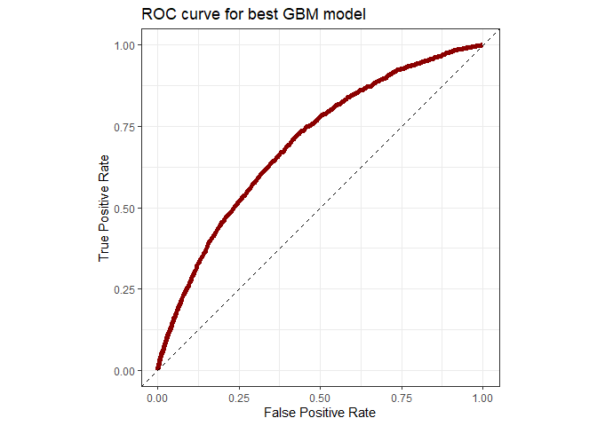

```r
# plot ROC curve for best model
# function to get performance metrics for the plot
getPerformanceMetrics <- function(model, newdata = NULL, xval = FALSE) {
  h2o.performance(model, newdata = newdata, xval = xval)@metrics$thresholds_and_metric_scores %>%
    as_tibble() %>%
    mutate(model = model@model_id)
}

# calculate performance metrics
best_performance <- getPerformanceMetrics(best_gbm, xval = TRUE)

# create plot
ggplot(best_performance, aes(fpr, tpr)) +
  geom_path(color = "red4", size = 2) +
  geom_abline(slope = 1, intercept = 0, linetype = "dashed") +
  coord_fixed() +
  labs(x = "False Positive Rate", y = "True Positive Rate", title = "ROC curve for best GBM model")+
  theme_bw()
```

## Variable Importance Plots

As a final close look, we can take a look at the variable importance plot for the GBM model.

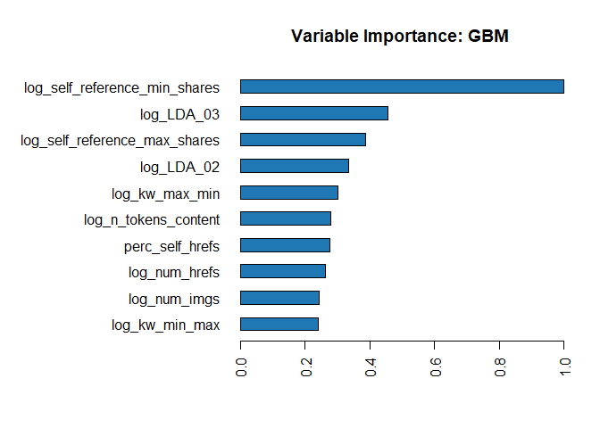

```r
# check variable importance
h2o.varimp_plot(best_gbm)
```

# Conclusion

Overall, this Kaggle competition shows the vast differences between model types as well as presents the duality in statistics of choosing between the best possible performance and sticking to the heralded statistics principles (holding on for dear life). The morale of the story is: forget the statistics playbook when you are in a competition, the rules are there to be bent, twisted and flipped.